# My visual data story

```javascript
$(function() {
  $(".level2").css('visibility', 'hidden');
  $(".level2").first().css('visibility', 'visible');
  $(".container-fluid").height($(".container-fluid").height() + 300);
  $(window).on('scroll', function() {
    $('h2').each(function() {
      var h2Top = $(this).offset().top - $(window).scrollTop();
      var windowHeight = $(window).height();
      if (h2Top >= 0 && h2Top <= windowHeight / 2) {
        $(this).parent('div').css('visibility', 'visible');
      } else if (h2Top > windowHeight / 2) {
        $(this).parent('div').css('visibility', 'hidden');
      }
    });
  });
})
```

## Introduction

Graffiti is an ever-present feature of urban landscapes, with each piece offering insight into public sentiment, artistic culture, or political expression. For this visual data story, I recorded and analysed graffiti observations throughout Auckland. My observations focused on key characteristics such as size, artistic quality, political nature, and textual presence.

## Plot 1: Graffiti Size vs Political Nature

This plot uses a bar chart to compare the count of graffiti pieces across three size categories, further separated by whether the graffiti was political in nature. I applied `geom_bar(position = "dodge")` to enable side-by-side comparisons. This helps evaluate whether political messages are more likely in larger or smaller pieces.

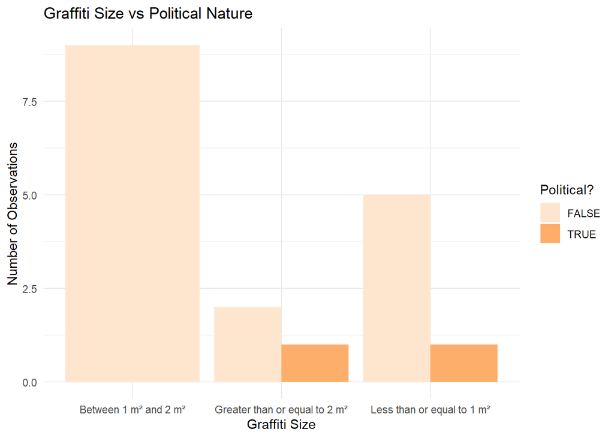

## Plot 2: Average Artistic Quality by Location

To assess where the most artistic graffiti is found, I used `group_by()` and `summarise()` to compute average artistic scores by location. A horizontal bar chart created with `geom_col()` makes these differences clear, with labels and axis orientation improving readability.

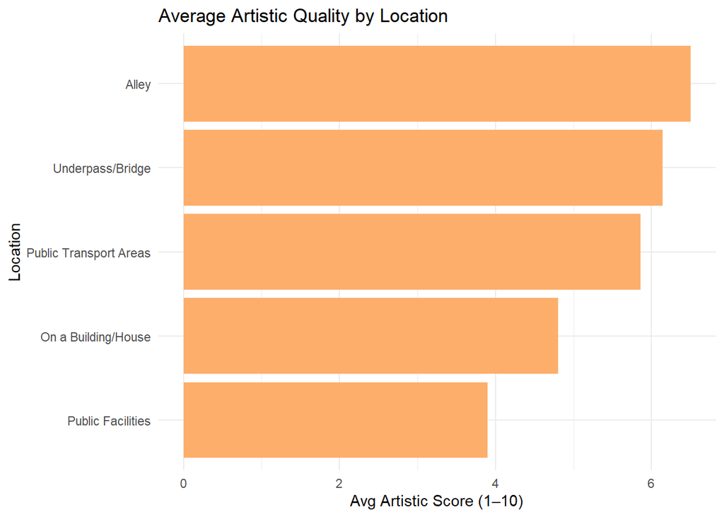

## Plot 3: Average Artistic Quality by Graffiti Size

Using `summarise()` again, I calculated the average artistic quality for each graffiti size category. I used `geom_col()` to depict the relationship between perceived artistic quality and the size of graffiti, highlighting whether larger artworks are rated more aesthetically.

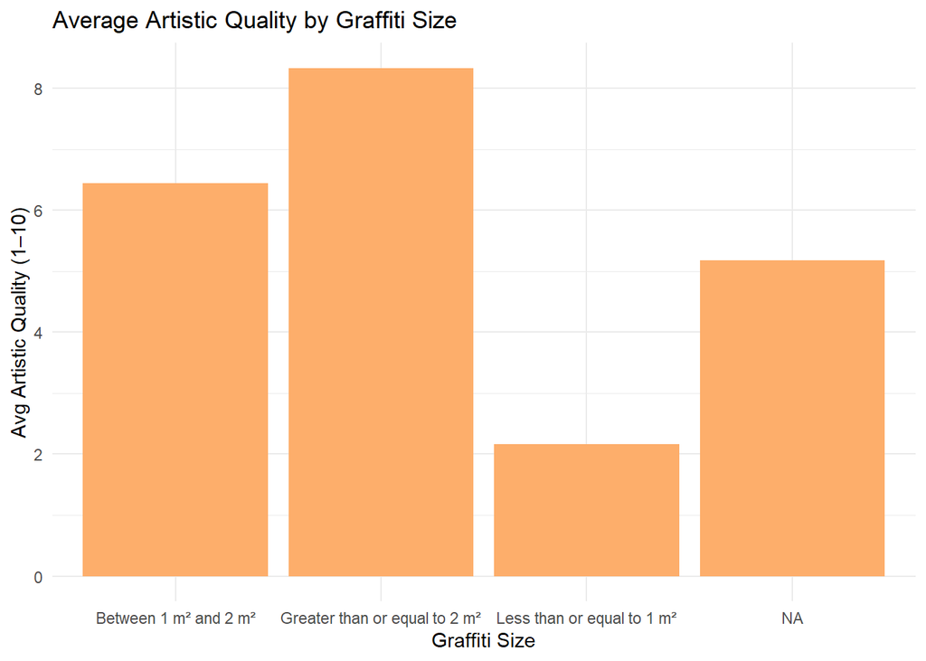

## Enhanced Visual: Plot + Real-World Graffiti Image

To blend data with real-world imagery, I used the `{magick}` package to overlay a plot onto a high-resolution photo from Pexels. This creative step visually connects statistical summaries to tangible street art and demonstrates R’s capacity for multimedia integration.

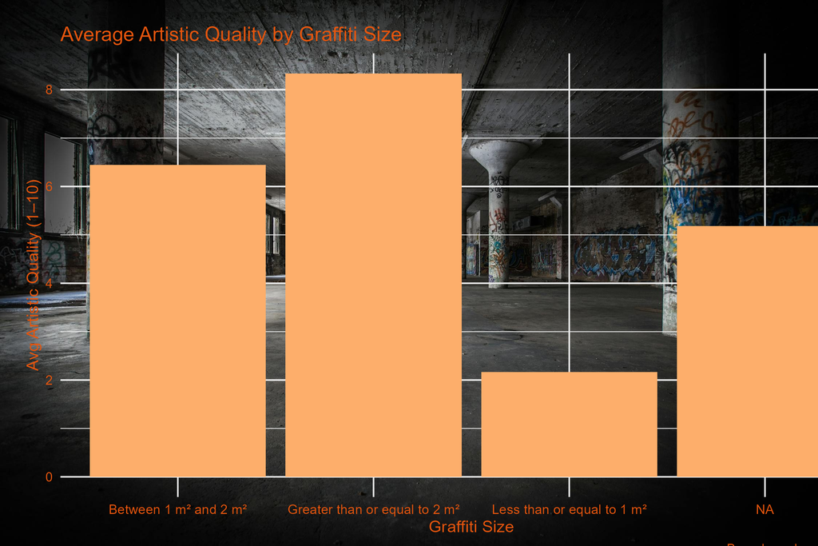

## Conclusion

This visual data story shows how size, political message, and location intersect to create different graffiti outcomes across Auckland. By combining grouped summaries, grammar of graphics principles, and visual design, I produced a narrative-driven look at graffiti trends across the city.

## Blank Test Scroll

This is to test the scroll effect